# Overview

Ian Lyttle

2018-10-24

Source: [`vignettes/overview.Rmd`](https://github.com/ijlyttle/bsplus/blob/master/vignettes/overview.Rmd)

One of the goals of **bsplus** is to provide access to some useful Bootstrap components for **rmarkdown** html-documents and **shiny** apps:

- Basic components: [button](http://getbootstrap.com/css/#buttons), [panel](http://getbootstrap.com/components/#panels), and [well](http://getbootstrap.com/components/#wells)
- Collapsible components: collapse and accordion
- Tools to help with documentation: [tooltip](http://getbootstrap.com/javascript/#tooltips), [popover](http://getbootstrap.com/javascript/#popovers), and [modal](http://getbootstrap.com/javascript/#modals), talk about the responsive embed function, once it is made.
- Present more information: carousel

Another goal is to provide some tools to help build **shiny** apps.

- `bs_accordion_sidebar()`: a framework, much like `shiny::navbarPage()`, to organize the UI of your **shiny** apps. For example, please see its [article](https://ijlyttle.github.io/bsplus/articles/accordion_sidebar.html), or this [**shiny** app](https://ijlyttle.shinyapps.io/accordion_sidebar/).
- `shinyInput_label_embed()`, `shiny_iconlink()`: functions to make it easier to embed help (tooltip, popover, or modal) into a **shiny** input. For example, please see this [**shiny** app](https://ijlyttle.shinyapps.io/tooltip_popover_modal/).

The philosophy of this package is to allow you to work with Bootstrap JavaScript components using HTML, while smoothing some of the rough edges. Even though some of the functions here are useful only in **shiny** apps, please note that none of the functions in this package depend on the server side of **shiny** - only the UI side.

## Components

This family of functions is used to build some stand-alone components.

### Button

```r
bs_button("This button does nothing", button_type = "warning")
```

### Panel

### Well

## Collapse

A collapsible element is attached to a button or link, which is used to show (or hide) the element.

The first step is to create the collapsible element, using `bs_collapse()` with an `id`. By default, this element is initially hidden.

```r
bs_collapse(
  id = "ex_collapse",
  content = tags$div(class = "well", "Yeah Yeah Yeah")
)
```

Yeah Yeah Yeah

Next, you create a tag, like a button, a then *attach* the `id` of the collapsible element to it.

```r
bs_button("She Loves You", button_type = "primary") %>%
  bs_attach_collapse("ex_collapse")
```

To see more of the collapse function-family, please see [its article](https://ijlyttle.github.io/bsplus/articles/collapse.html).

## Accordion

An accordion is a set of collapsible panels constructed such that one panel, at most, is open at a time.

There are two main functions:

- `bs_accordion()`, used to establish the accordion framework
- `bs_append()`, used to add a panel (`title` and `content`) to the accordion.

Generally, `title` will be text, and `content` can be HTML.

```r
bs_accordion(id = "meet_the_beatles") %>%
  bs_append(title = "John", content = "Rhythm guitar, vocals") %>%
  bs_append(title = "Paul", content = "Bass guitar, vocals") %>%
  bs_append(title = "George", content = "Lead guitar, vocals") %>%
  bs_append(title = "Ringo", content = "Drums, vocals")
```

Rhythm guitar, vocals

Bass guitar, vocals

Lead guitar, vocals

Drums, vocals

To see more of the `bs_accordion()` function-family, including how to make the entire banner “clickable” and how to change the class of the panels, please see [its article](https://ijlyttle.github.io/bsplus/articles/accordion.html).

## Accordion sidebar

An accordion-sidebar can be useful to provide another dimension for your **shiny** apps. For example, you can use **shiny** `navbarPage()` for major groupings, then `bs_accordion_sidebar()` panels for minor groupings within each major grouping.

There like the accordion, there are two main functions:

- `bs_accordion_sidebar()`, used to establish the accordion-sidebar framework
- `bs_append()`, used to add a side panel (`title_side` and `content_side`) and a main panel (`content_main`) to the accordion sidebar

Generally, `title_side` will be text, `content_side` can be HTML (**shiny** inputs), as well as `content_main` (**shiny** outputs).

```r
bs_accordion_sidebar(id = "beatles") %>%
  bs_append(
    title_side = "John Lennon",
    content_side = "Rhythm guitar, vocals",
    content_main = "Dear Prudence"
  ) %>%
  bs_append(
    title_side = "Paul McCartney",
    content_side = "Bass guitar, vocals",
    content_main = "Blackbird"
  ) %>%
  bs_append(
    title_side = "George Harrison",
    content_side = "Lead guitar, vocals",
    content_main = "While My Guitar Gently Weeps"
  ) %>%
  bs_append(
    title_side = "Ringo Starr",
    content_side = "Drums, vocals",
    content_main = "Don't Pass Me By"
  )
```

Rhythm guitar, vocals

Bass guitar, vocals

Lead guitar, vocals

Drums, vocals

Dear Prudence

Blackbird

While My Guitar Gently Weeps

Don't Pass Me By

As you can see, the sidebar acts like a `bs_accordion()`, but there are a couple of important differences. First, a sidebar panel’s class changes according to its being open or not. Second, the state (show-hide) of each component’s main panel is determined by the state of its side panel.

This extra functionality is implemented using some JavaScript code inserted into your page using the `use_bs_accordion_sidebar()` function. You will have to do this only once per page; I have found that it works best to include after all of the accordion-sidebars are defined, perhaps as one of the last elements in a **shiny** UI.

```r
use_bs_accordion_sidebar()
```

To see more of the `bs_accordion_sidebar()` function-family, including how to change the active/inactive classes, size and placement of the sidebar and main panels, and formatting of the main panel, please see [its article](https://ijlyttle.github.io/bsplus/articles/accordion_sidebar.html). You can also see this in action in a [**shiny** app](https://ijlyttle.shinyapps.io/accordion_sidebar/).

## Modal

Modal windows are a great way to deliver help-documentation, although they certainly have other uses.

The first step is to define a modal widow, giving it an `id`. The **shiny** function `includeMarkdown()` can be useful to compose the content.

```r
bs_modal(
  id = "modal_markdown",
  title = "Using Markdown",
  body = includeMarkdown(system.file("markdown", "modal.md", package = "bsplus"))
)
```

To allow activation of the modal window, attach its `id` to a button (or link).

```r
bs_button("Click for modal", button_type = "primary") %>%
  bs_attach_modal("modal_markdown")
```

The verb *attach* implies that you can attach an `id` to as many links you like. Thus:

```r
bs_button("New button, same modal", button_type = "primary") %>%
  bs_attach_modal("modal_markdown")
```

To see more of the `bs_modal()` function-family, including how to specify the size of the modal, please see [its article](https://ijlyttle.github.io/bsplus/articles/modal.html).

## Tooltip

A tooltip can be used to embed a short note into a tag; by default they are activated by hovering over the tag.

```r
bs_button("John Lennon", button_type = "default") %>%
  bs_embed_tooltip(title = "Rhythm Guitar, vocals")
```

According to the [Bootstrap site](http://getbootstrap.com/javascript/#tooltips), tooltips are not activated automatically; to activate them you can call `use_bs_tooltip()` once on your page.

```r
use_bs_tooltip()
```

To see more of the `bs_embed_tooltip()` function, including how to specify the placement of the tooltip, please see [its article](https://ijlyttle.github.io/bsplus/articles/tooltip_popover.html).

## Popover

A popover can be used to embed a longer note into a tag; by default they are activated by clicking on the tag. A popover has a `title`, which is generally text, and `content`, which can be HTML.

```r
bs_button("John Lennon", button_type = "default") %>%
  bs_embed_popover(
    title = "More information",
    content = "Although he wrote \"I Am the Walrus\",
               he later insisted that the Walrus was Paul."
  )
```

```r
use_bs_popover()
```

To see more of the `bs_embed_popover()` function, including how to specify the placement of the popover, please see [its article](https://ijlyttle.github.io/bsplus/articles/tooltip_popover.html).

## Carousel

An carousel can be useful to cycle through slides with related content. There like the accordion, there are two main functions:

- `bs_carousel()`, used to establish the carousel framework
- `bs_append()`, used to add a slide containing `content`, which is HTML, and an optional `caption`

[figure not shown]

```r
bs_carousel(id = "the_beatles", use_indicators = TRUE) %>%
  bs_append(
    content = bs_carousel_image(src = image_uri("img/john.jpg")),
    caption = bs_carousel_caption("John Lennon", "Rhythm guitar, vocals")
  ) %>%
  bs_append(
    content = bs_carousel_image(src = image_uri("img/paul.jpg")),
    caption = bs_carousel_caption("Paul McCartney", "Bass guitar, vocals")
  ) %>%
  bs_append(
    content = bs_carousel_image(src = image_uri("img/george.jpg")),
    caption = bs_carousel_caption("George Harrison", "Lead guitar, vocals")
  ) %>%
  bs_append(
    content = bs_carousel_image(src = image_uri("img/ringo.jpg")),
    caption = bs_carousel_caption("Ringo Starr", "Drums, vocals")
  )
```

### John Lennon

Rhythm guitar, vocals

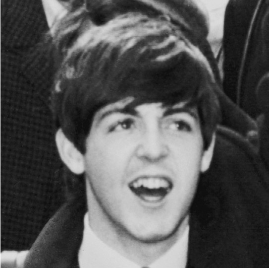

### Paul McCartney

Bass guitar, vocals

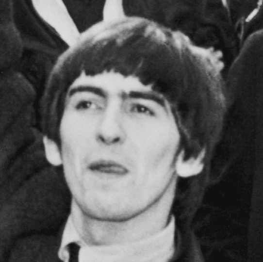

### George Harrison

Lead guitar, vocals

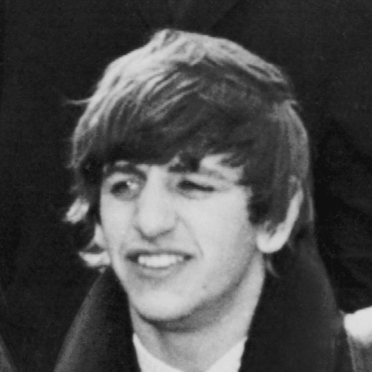

### Ringo Starr

Drums, vocals

I think the carousel has potential not shown in this example. The content of each slide is HTML, so a carousel could contain images (as shown here), **shiny** inputs or outputs. Another possibility may be to use the the `frame` aesthetic offered by **gganimate** to cycle through **ggplot2** plots.

To see more of the `bs_carousel()` framework, including its helper functions `bs_carousel_image()` and `bs_carousel_caption()`, please see [its article](https://ijlyttle.github.io/bsplus/articles/carousel.html).

## Help links

If you want to include help links in your **shiny** app, some functions in this package can help you do that.

Let’s consider a **shiny** input. One way to put unobtrusive help into a **shiny** input is to embed a help icon into its label, having associated the help icon with the help documentation. This suggests three steps:

1. Create a help icon. You can use `shiny::icon()` or `shiny_iconlink()` (which simply wraps the icon in an HTML link).
2. Associate the help icon with your help documentation. Here, you can use `bs_embed_tooltip()`, `bs_embed_popover()` or `bs_attach_modal()`.
3. Embed your help icon into the **shiny** input. You can use `shinyInput_label_embed()`.

Here’s an example of everything put together:

```r
selectInput(
  inputId = "letter",
  label = "Label with popover help",
  choices = c("a", "b", "c")
) %>%
shinyInput_label_embed(
  shiny_iconlink() %>%
  bs_embed_popover(
    title = "Letter", content = "Choose a favorite", placement = "left"
  )
)
```

As of writing, I don’t know how to include operable **shiny** inputs in an html document, outside of the **shiny** runtime. To see these functions in action, you can refer to this [**shiny** app](https://ijlyttle.shinyapps.io/tooltip_popover_modal/#), which you can also run locally using:

```r
shiny::runApp(system.file("shiny", "tooltip_popover_modal", package = "bsplus"))
```

Here’s what it looks like:

[figure not shown]

To see more of the help-link framework, including more examples and a proposed convention for icons, please read [this article](https://ijlyttle.github.io/bsplus/articles/shiny_help_links.html).

## Helper functions

Finally, there are a couple of helper functions for customizing Bootstrap tags: `bs_set_data()` and `bs_set_aria()`. These can be useful because not all of the options for Bootstrap components are represented in the arguments of functions in this package.

Consider the [options for popovers](http://getbootstrap.com/javascript/#popovers-options); there are close to a dozen. The only one that I thought might be commonly used was `placement`, so this became an explicit argument to `bs_embed_popover()`.

Let’s say that you want to be able to dismiss a popover by clicking anywhere in the browser window other than the button. To do this, you have to set the attribute `data-trigger` to the value `"focus"`. The function `bs_set_data()` makes things a little easier for you by prepending `"data-"` to each name and serializing the values to the format specified by the Bootstrap API.

The `bs_embed_popover()` function has a `...` argument; any such additional arguments are passed to `bs_set_data()`. Thus, you can add this `trigger` argument to `bs_embed_popover()`.

```r
bs_button("Click for popover", button_type = "primary") %>%
  bs_embed_popover(
    title = "To dismiss",
    content = "Click anywhere in the browser window, except the button.",
    trigger = "focus"
  )
```

Both of these functions are used to set attributes on tags; `bs_set_data()` is used for attributes that start with `"data-"`, `bs_set_aria()` is used for attributes that start with `"aria-"`. To see more of these helper functions, please read [their reference](https://ijlyttle.github.io/bsplus/reference/bs_set_data.html).